# Setting Up the Environment

### From the above code, we can establish that the columns, payment_method, city, store_type, discount_applied, customer_category, season, promotion, in retail_df are categorical variable

#### Payment_Method: One-hot encoding.

#### City: One-hot encoding or frequency encoding.

#### Store_Type: One-hot encoding or label encoding (if order exists).

#### Discount_Applied: Binary encoding (0/1).

#### Customer_Category: One-hot encoding or label encoding.

#### Season: One-hot encoding or label encoding.

#### Promotion: One-hot encoding.

```python
# encoding the categprical variables using one-hot encoding

encoded_retail_df = retail_df.copy()

cols =  ['Payment_Method', 'Store_Type', 'Customer_Category', 'Season', 'Promotion']

for col in cols:
  dummies = pd.get_dummies(retail_df[col], prefix = col, drop_first = True)
  encoded_retail_df = pd.concat([encoded_retail_df, dummies.astype(int)], axis = 1)
  encoded_retail_df.drop([col], axis = 1, inplace = True)

encoded_retail_df.head()
```

|  | Transaction_ID | Date | Customer_Name | Product | Total_Items | Total_Cost | City | Discount_Applied | Payment_Method_Credit Card | Payment_Method_Debit Card | ... | Customer_Category_Retiree | Customer_Category_Senior Citizen | Customer_Category_Student | Customer_Category_Teenager | Customer_Category_Young Adult | Season_Spring | Season_Summer | Season_Winter | Promotion_Discount on Selected Items | Promotion_No Promotion |
| --- | --- | --- | --- | --- | --- | --- | --- | --- | --- | --- | --- | --- | --- | --- | --- | --- | --- | --- | --- | --- | --- |
| 0 | 1000000000 | 2022-01-21 06:27:29 | Stacey Price | ['Ketchup', 'Shaving Cream', 'Light Bulbs'] | 3 | 71.65 | Los Angeles | True | 0 | 0 | ... | 0 | 0 | 0 | 0 | 0 | 0 | 0 | 1 | 0 | 1 |
| 1 | 1000000001 | 2023-03-01 13:01:21 | Michelle Carlson | ['Ice Cream', 'Milk', 'Olive Oil', 'Bread', 'P... | 2 | 25.93 | San Francisco | True | 0 | 0 | ... | 0 | 0 | 0 | 0 | 0 | 0 | 0 | 0 | 0 | 0 |
| 2 | 1000000002 | 2024-03-21 15:37:04 | Lisa Graves | ['Spinach'] | 6 | 41.49 | Houston | True | 1 | 0 | ... | 0 | 0 | 0 | 0 | 0 | 0 | 0 | 1 | 0 | 1 |
| 3 | 1000000003 | 2020-10-31 09:59:47 | Mrs. Patricia May | ['Tissues', 'Mustard'] | 1 | 39.34 | Chicago | True | 0 | 0 | ... | 0 | 0 | 0 | 0 | 0 | 1 | 0 | 0 | 0 | 1 |
| 4 | 1000000004 | 2020-12-10 00:59:59 | Susan Mitchell | ['Dish Soap'] | 10 | 16.42 | Houston | False | 0 | 1 | ... | 0 | 0 | 0 | 0 | 1 | 0 | 0 | 1 | 1 | 0 |

5 rows × 28 columns

```python
# encoding Discount_Applied column using Binary encoder (0/1)

encoder = ce.BinaryEncoder(cols = ['Discount_Applied'])
encoded_retail_df = encoder.fit_transform(encoded_retail_df)
encoded_retail_df.head()
```

|  | Transaction_ID | Date | Customer_Name | Product | Total_Items | Total_Cost | City | Discount_Applied_0 | Discount_Applied_1 | Payment_Method_Credit Card | ... | Customer_Category_Retiree | Customer_Category_Senior Citizen | Customer_Category_Student | Customer_Category_Teenager | Customer_Category_Young Adult | Season_Spring | Season_Summer | Season_Winter | Promotion_Discount on Selected Items | Promotion_No Promotion |
| --- | --- | --- | --- | --- | --- | --- | --- | --- | --- | --- | --- | --- | --- | --- | --- | --- | --- | --- | --- | --- | --- |
| 0 | 1000000000 | 2022-01-21 06:27:29 | Stacey Price | ['Ketchup', 'Shaving Cream', 'Light Bulbs'] | 3 | 71.65 | Los Angeles | 0 | 1 | 0 | ... | 0 | 0 | 0 | 0 | 0 | 0 | 0 | 1 | 0 | 1 |
| 1 | 1000000001 | 2023-03-01 13:01:21 | Michelle Carlson | ['Ice Cream', 'Milk', 'Olive Oil', 'Bread', 'P... | 2 | 25.93 | San Francisco | 0 | 1 | 0 | ... | 0 | 0 | 0 | 0 | 0 | 0 | 0 | 0 | 0 | 0 |
| 2 | 1000000002 | 2024-03-21 15:37:04 | Lisa Graves | ['Spinach'] | 6 | 41.49 | Houston | 0 | 1 | 1 | ... | 0 | 0 | 0 | 0 | 0 | 0 | 0 | 1 | 0 | 1 |
| 3 | 1000000003 | 2020-10-31 09:59:47 | Mrs. Patricia May | ['Tissues', 'Mustard'] | 1 | 39.34 | Chicago | 0 | 1 | 0 | ... | 0 | 0 | 0 | 0 | 0 | 1 | 0 | 0 | 0 | 1 |
| 4 | 1000000004 | 2020-12-10 00:59:59 | Susan Mitchell | ['Dish Soap'] | 10 | 16.42 | Houston | 1 | 0 | 0 | ... | 0 | 0 | 0 | 0 | 1 | 0 | 0 | 1 | 1 | 0 |

5 rows × 29 columns

# Checking for normality of the columns to decide which scaler to apply to scale the data

```python
def check_normality(data, col):
    plt.figure(figsize=(15, 5))

    # Histogram for the col in data
    plt.subplot(1, 2, 1)
    sns.histplot(data[col], bins=10, kde=True, line_kws={'color': 'crimson', 'ls': '--'})
    plt.title(f'Histogram of {col}')

    # Q-Q plot using scipy
    plt.subplot(1, 2, 2)
    stats.probplot(data[col], dist='norm', plot=plt)
    plt.title(f"Q-Q plot for {col} (Scipy)")

    # Q-Q plot using statsmodels.api
    sm.qqplot(data[col], line='s')
    plt.title(f"Q-Q plot for {col} (Statsmodels)")

    plt.tight_layout()
    plt.show()

    # Shapiro-Wilk Test
    statistics, p_value = shapiro(data[col])
    print(f"Shapiro-Wilk Test for {col}:")
    print(f"Statistics: {statistics}")
    print(f"P-value: {p_value}")

    if p_value > 0.05:
        print(f"The {col} is normally distributed [fail to reject H0]")
    else:
        print(f"The {col} is not normally distributed [reject H0]")
```

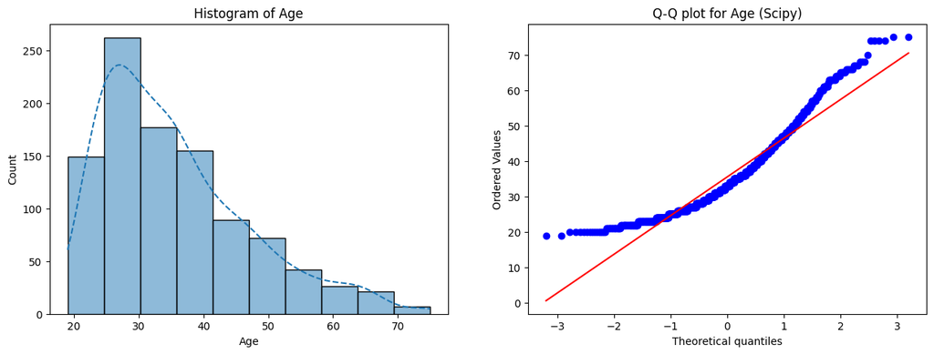

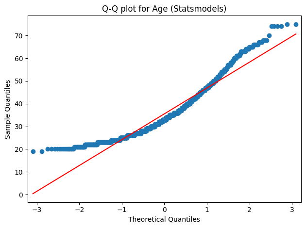

```
Shapiro-Wilk Test for Age:
Statistics: 0.917471229910265
P-value: 6.382098308916094e-23
The Age is not normally distributed [reject H0]
```

```python
check_normality(encoded_german_df, 'Age')
```

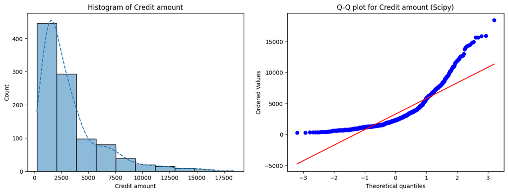

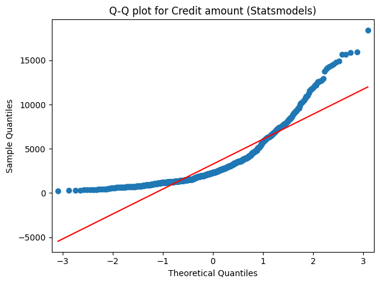

```
Shapiro-Wilk Test for Credit amount:
Statistics: 0.7933961638083256
P-value: 8.608545621331088e-34
The Credit amount is not normally distributed [reject H0]
```

```python
check_normality(encoded_german_df, 'Credit amount')
```

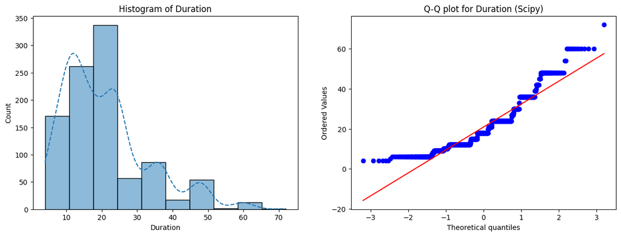

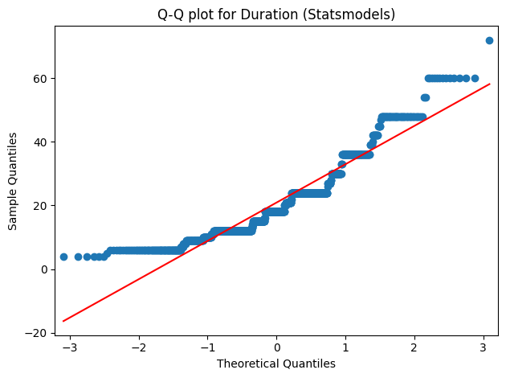

```
Shapiro-Wilk Test for Duration:
Statistics: 0.8997879376569183
P-value: 4.906432642671475e-25
The Duration is not normally distributed [reject H0]
```

```python
check_normality(encoded_german_df, 'Duration')
```

## Checking for outliers

```python
def check_outliers(data, col):
  # Box plot
  sns.boxplot(data[col])
  plt.title(f"Box plot for {col}")
  plt.show()
```

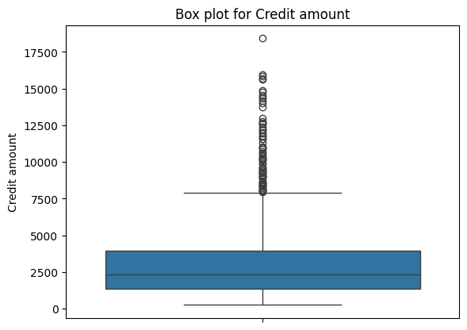

```python
check_outliers(encoded_german_df, 'Credit amount')
```

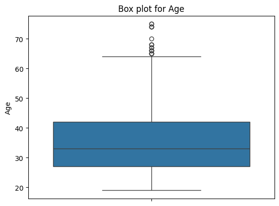

```python
check_outliers(encoded_german_df, 'Age')
```

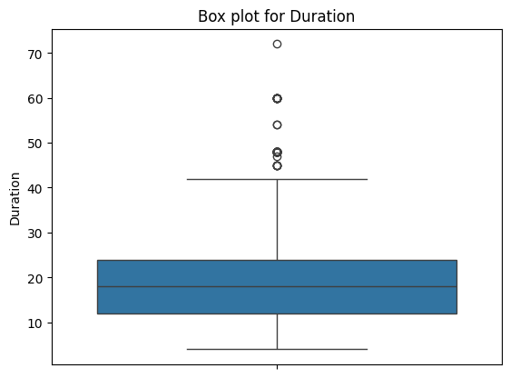

```python
check_outliers(encoded_german_df, 'Duration')
```

## Removing the outliers from the data

```python
def remove_outiers(data, col):
  Q1 = data[col].quantile(0.25)
  Q3 = data[col].quantile(0.75)
  IQR = Q3 - Q1
  lower_bound = Q1 - (1.5 * IQR)
  upper_bound = Q3 + (1.5 * IQR)
  filtered_data = (data[col] >= lower_bound) & (data[col] <= upper_bound)
  return data[filtered_data]
```

```python
encoded_german_cleaned_df = remove_outiers(encoded_german_df, 'Credit amount')
encoded_german_cleaned_df = remove_outiers(encoded_german_cleaned_df, 'Age')
encoded_german_cleaned_df = remove_outiers(encoded_german_cleaned_df, 'Duration')
encoded_german_cleaned_df.head()
```

|  | Unnamed: 0 | Age | Job | Saving accounts | Checking account | Credit amount | Duration | Sex_male | Housing_own | Housing_rent | Purpose_car | Purpose_domestic appliances | Purpose_education | Purpose_furniture/equipment | Purpose_radio/TV | Purpose_repairs | Purpose_vacation/others |
| --- | --- | --- | --- | --- | --- | --- | --- | --- | --- | --- | --- | --- | --- | --- | --- | --- | --- |
| 2 | 2 | 49 | 1 | 0.0 | 0 | 2096 | 12 | 1 | 1 | 0 | 0 | 0 | 1 | 0 | 0 | 0 | 0 |
| 3 | 3 | 45 | 2 | 0.0 | 0 | 7882 | 42 | 1 | 0 | 0 | 0 | 0 | 0 | 1 | 0 | 0 | 0 |
| 4 | 4 | 53 | 2 | 0.0 | 0 | 4870 | 24 | 1 | 0 | 0 | 1 | 0 | 0 | 0 | 0 | 0 | 0 |
| 6 | 6 | 53 | 2 | 3.0 | 0 | 2835 | 24 | 1 | 1 | 0 | 0 | 0 | 0 | 1 | 0 | 0 | 0 |
| 7 | 7 | 35 | 3 | 0.0 | 1 | 6948 | 36 | 1 | 0 | 1 | 1 | 0 | 0 | 0 | 0 | 0 | 0 |

## Checking the information and Visualizing the data after removing the outliers

```python
encoded_german_cleaned_df.describe()
```

|  | Unnamed: 0 | Age | Job | Saving accounts | Checking account | Credit amount | Duration | Sex_male | Housing_own | Housing_rent | Purpose_car | Purpose_domestic appliances | Purpose_education | Purpose_furniture/equipment | Purpose_radio/TV | Purpose_repairs | Purpose_vacation/others |
| --- | --- | --- | --- | --- | --- | --- | --- | --- | --- | --- | --- | --- | --- | --- | --- | --- | --- |
| count | 862.000000 | 862.000000 | 862.000000 | 862.000000 | 862.000000 | 862.000000 | 862.000000 | 862.000000 | 862.000000 | 862.000000 | 862.000000 | 862.000000 | 862.000000 | 862.000000 | 862.000000 | 862.000000 | 862.000000 |
| mean | 500.156613 | 34.698376 | 1.866589 | 0.404872 | 0.385151 | 2531.432715 | 18.116009 | 0.677494 | 0.735499 | 0.189095 | 0.322506 | 0.012761 | 0.056845 | 0.201856 | 0.295824 | 0.022042 | 0.005800 |
| std | 287.025771 | 10.264763 | 0.622514 | 0.863305 | 0.613561 | 1663.627810 | 8.690069 | 0.467707 | 0.441323 | 0.391812 | 0.467707 | 0.112307 | 0.231680 | 0.401618 | 0.456677 | 0.146905 | 0.075984 |
| min | 2.000000 | 19.000000 | 0.000000 | 0.000000 | 0.000000 | 250.000000 | 4.000000 | 0.000000 | 0.000000 | 0.000000 | 0.000000 | 0.000000 | 0.000000 | 0.000000 | 0.000000 | 0.000000 | 0.000000 |
| 25% | 251.250000 | 27.000000 | 2.000000 | 0.000000 | 0.000000 | 1308.250000 | 12.000000 | 0.000000 | 0.000000 | 0.000000 | 0.000000 | 0.000000 | 0.000000 | 0.000000 | 0.000000 | 0.000000 | 0.000000 |
| 50% | 498.500000 | 33.000000 | 2.000000 | 0.000000 | 0.000000 | 2066.500000 | 18.000000 | 1.000000 | 1.000000 | 0.000000 | 0.000000 | 0.000000 | 0.000000 | 0.000000 | 0.000000 | 0.000000 | 0.000000 |
| 75% | 746.750000 | 41.000000 | 2.000000 | 0.000000 | 1.000000 | 3355.000000 | 24.000000 | 1.000000 | 1.000000 | 0.000000 | 1.000000 | 0.000000 | 0.000000 | 0.000000 | 1.000000 | 0.000000 | 0.000000 |
| max | 997.000000 | 64.000000 | 3.000000 | 3.000000 | 2.000000 | 7882.000000 | 42.000000 | 1.000000 | 1.000000 | 1.000000 | 1.000000 | 1.000000 | 1.000000 | 1.000000 | 1.000000 | 1.000000 | 1.000000 |

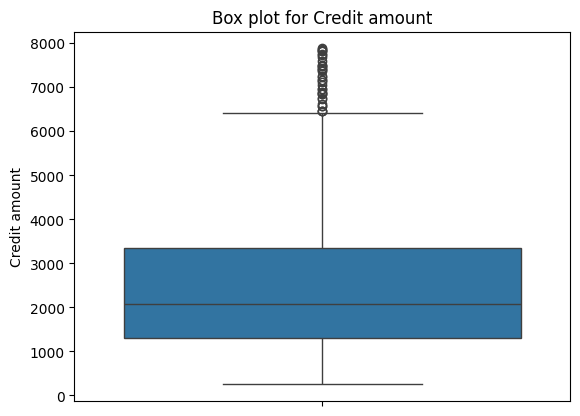

```python
check_outliers(encoded_german_cleaned_df, 'Credit amount')
```

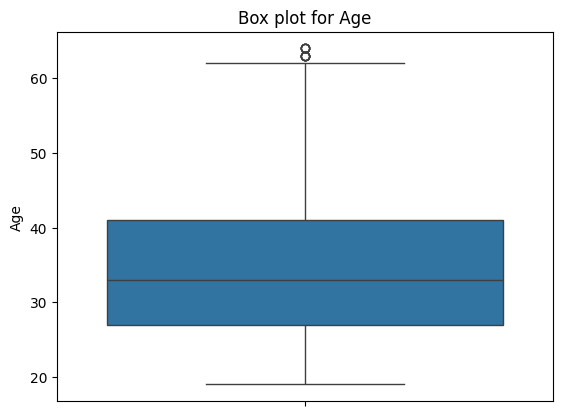

```python
check_outliers(encoded_german_cleaned_df, 'Age')
```

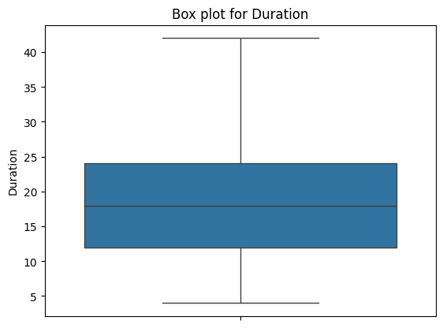

```python
check_outliers(encoded_german_cleaned_df, 'Duration')
```

## Check the remaining outliers to be sure that they are legitimate and plausible values

```python
def check_remaining_outliers(data, col):
  print(f"Remaining outliers in {col}")
  Q1 = data[col].quantile(0.25)
  Q3 = data[col].quantile(0.75)
  lower_bound = Q1 - (1.5 * (Q3 - Q1))
  upper_bound = Q3 + (1.5 * (Q3 - Q1))
  outliers = data[(data[col] < lower_bound) | (data[col] > upper_bound)]
  # print(outliers[col])
  print(outliers)
  print()
```

```python
check_remaining_outliers(encoded_german_cleaned_df, 'Credit amount')
check_remaining_outliers(encoded_german_cleaned_df, 'Age')
check_remaining_outliers(encoded_german_cleaned_df, 'Duration')
```

```
Remaining outliers in Credit amount
     Unnamed: 0  Age  Job  Saving accounts  Checking account  Credit amount  \
3             3   45    2              0.0                 0           7882
7             7   35    3              0.0                 1           6948
48           48   39    1              0.0                 0           7228
56           56   52    3              0.0                 1           6468
99           99   36    3              0.0                 1           7057
106         106   39    3              0.0                 0           6458
108         108   30    2              0.0                 0           7721
113         113   25    2              0.0                 0           7855
116         116   30    3              0.0                 0           7174
131         131   29    2              0.0                 0           6887
153         153   29    2              2.0                 1           7758
154         154   36    3              1.0                 1           6967
175         175   53    3              0.0                 0           7485
```

[output cut: 246 more lines]

### The remaining outliers seems plausible, therefore, we will keep them (at least for now)

## Scaling the features - Since they are not normally distributed, MinMAxScaler is the appropriate scaler

```python
scaler = MinMaxScaler()
encoded_german_cleaned_df[['Credit amount', 'Age', 'Duration']] = scaler.fit_transform(encoded_german_cleaned_df[['Credit amount', 'Age', 'Duration']])
encoded_german_cleaned_df.drop(['Unnamed: 0'], axis = 1, inplace = True)
encoded_german_cleaned_df.head()
```

|  | Age | Job | Saving accounts | Checking account | Credit amount | Duration | Sex_male | Housing_own | Housing_rent | Purpose_car | Purpose_domestic appliances | Purpose_education | Purpose_furniture/equipment | Purpose_radio/TV | Purpose_repairs | Purpose_vacation/others |
| --- | --- | --- | --- | --- | --- | --- | --- | --- | --- | --- | --- | --- | --- | --- | --- | --- |
| 2 | 0.666667 | 1 | 0.0 | 0 | 0.241876 | 0.210526 | 1 | 1 | 0 | 0 | 0 | 1 | 0 | 0 | 0 | 0 |
| 3 | 0.577778 | 2 | 0.0 | 0 | 1.000000 | 1.000000 | 1 | 0 | 0 | 0 | 0 | 0 | 1 | 0 | 0 | 0 |
| 4 | 0.755556 | 2 | 0.0 | 0 | 0.605346 | 0.526316 | 1 | 0 | 0 | 1 | 0 | 0 | 0 | 0 | 0 | 0 |
| 6 | 0.755556 | 2 | 3.0 | 0 | 0.338705 | 0.526316 | 1 | 1 | 0 | 0 | 0 | 0 | 1 | 0 | 0 | 0 |
| 7 | 0.355556 | 3 | 0.0 | 1 | 0.877621 | 0.842105 | 1 | 0 | 1 | 1 | 0 | 0 | 0 | 0 | 0 | 0 |

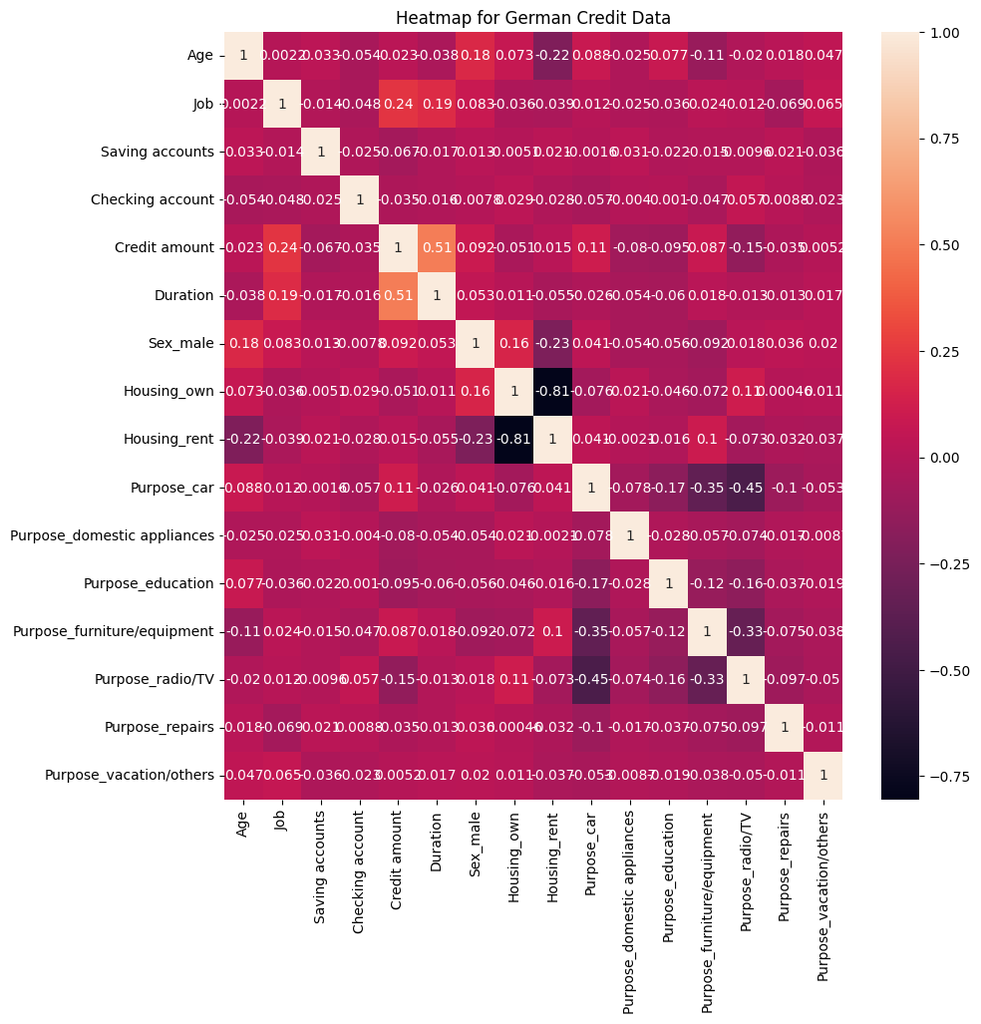

```python
plt.figure(figsize = (10, 10))
corr = encoded_german_cleaned_df.corr()
sns.heatmap(corr, annot = True)
plt.title("Heatmap for German Credit Data")
plt.show()
```

## Checking for normality and outliers in retail_df

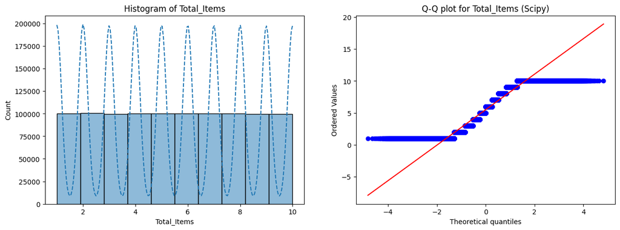

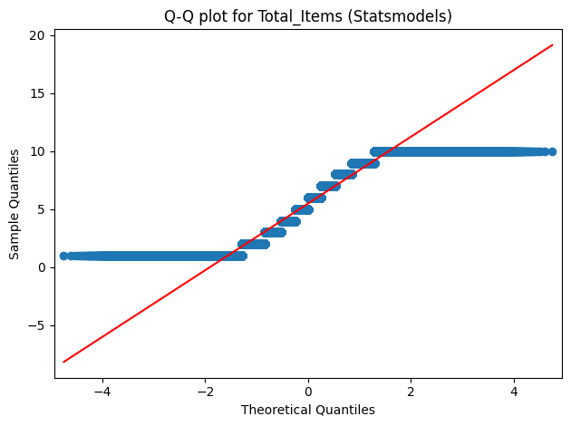

```
Shapiro-Wilk Test for Total_Items:
Statistics: 0.9354519255207762
P-value: 3.214766050541433e-140
The Total_Items is not normally distributed [reject H0]
```

```python
check_normality(encoded_retail_df, 'Total_Items')
```

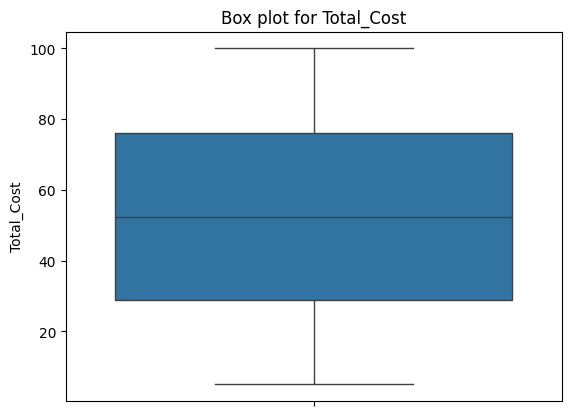

```python
check_outliers(encoded_retail_df, 'Total_Cost')
```

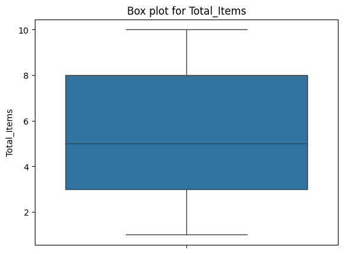

```python
check_outliers(encoded_retail_df, 'Total_Items')
```

## Scaling Total_Cost

```python
encoded_retail_df['Total_Cost'] = scaler.fit_transform(encoded_retail_df[['Total_Cost']])
encoded_retail_df.head()
```

|  | Transaction_ID | Date | Customer_Name | Product | Total_Items | Total_Cost | City | Discount_Applied_0 | Discount_Applied_1 | Payment_Method_Credit Card | ... | Customer_Category_Retiree | Customer_Category_Senior Citizen | Customer_Category_Student | Customer_Category_Teenager | Customer_Category_Young Adult | Season_Spring | Season_Summer | Season_Winter | Promotion_Discount on Selected Items | Promotion_No Promotion |
| --- | --- | --- | --- | --- | --- | --- | --- | --- | --- | --- | --- | --- | --- | --- | --- | --- | --- | --- | --- | --- | --- |
| 0 | 1000000000 | 2022-01-21 06:27:29 | Stacey Price | ['Ketchup', 'Shaving Cream', 'Light Bulbs'] | 3 | 0.701579 | Los Angeles | 0 | 1 | 0 | ... | 0 | 0 | 0 | 0 | 0 | 0 | 0 | 1 | 0 | 1 |
| 1 | 1000000001 | 2023-03-01 13:01:21 | Michelle Carlson | ['Ice Cream', 'Milk', 'Olive Oil', 'Bread', 'P... | 2 | 0.220316 | San Francisco | 0 | 1 | 0 | ... | 0 | 0 | 0 | 0 | 0 | 0 | 0 | 0 | 0 | 0 |
| 2 | 1000000002 | 2024-03-21 15:37:04 | Lisa Graves | ['Spinach'] | 6 | 0.384105 | Houston | 0 | 1 | 1 | ... | 0 | 0 | 0 | 0 | 0 | 0 | 0 | 1 | 0 | 1 |
| 3 | 1000000003 | 2020-10-31 09:59:47 | Mrs. Patricia May | ['Tissues', 'Mustard'] | 1 | 0.361474 | Chicago | 0 | 1 | 0 | ... | 0 | 0 | 0 | 0 | 0 | 1 | 0 | 0 | 0 | 1 |
| 4 | 1000000004 | 2020-12-10 00:59:59 | Susan Mitchell | ['Dish Soap'] | 10 | 0.120211 | Houston | 1 | 0 | 0 | ... | 0 | 0 | 0 | 0 | 1 | 0 | 0 | 1 | 1 | 0 |

5 rows × 29 columns

```python
X = encoded_german_cleaned_df.drop(columns=['Sex_male', 'Housing_own', 'Housing_rent', 'Purpose_car',
                                            'Purpose_domestic appliances', 'Purpose_education', 'Purpose_furniture/equipment',
                                            'Purpose_radio/TV', 'Purpose_repairs', 'Purpose_vacation/others'])
temp_df = encoded_german_cleaned_df.copy()

k_means = KMeans(n_clusters = 3, random_state = 42)
k_means.fit(X)
clusters = k_means.predict(X)
temp_df['Cluster'] = clusters
temp_df.head()
```

|  | Age | Job | Saving accounts | Checking account | Credit amount | Duration | Sex_male | Housing_own | Housing_rent | Purpose_car | Purpose_domestic appliances | Purpose_education | Purpose_furniture/equipment | Purpose_radio/TV | Purpose_repairs | Purpose_vacation/others | Cluster |
| --- | --- | --- | --- | --- | --- | --- | --- | --- | --- | --- | --- | --- | --- | --- | --- | --- | --- |
| 2 | 0.666667 | 1 | 0.0 | 0 | 0.241876 | 0.210526 | 1 | 1 | 0 | 0 | 0 | 1 | 0 | 0 | 0 | 0 | 0 |
| 3 | 0.577778 | 2 | 0.0 | 0 | 1.000000 | 1.000000 | 1 | 0 | 0 | 0 | 0 | 0 | 1 | 0 | 0 | 0 | 0 |
| 4 | 0.755556 | 2 | 0.0 | 0 | 0.605346 | 0.526316 | 1 | 0 | 0 | 1 | 0 | 0 | 0 | 0 | 0 | 0 | 0 |
| 6 | 0.755556 | 2 | 3.0 | 0 | 0.338705 | 0.526316 | 1 | 1 | 0 | 0 | 0 | 0 | 1 | 0 | 0 | 0 | 2 |
| 7 | 0.355556 | 3 | 0.0 | 1 | 0.877621 | 0.842105 | 1 | 0 | 1 | 1 | 0 | 0 | 0 | 0 | 0 | 0 | 1 |

```python
X.columns
```

```
Index(['Age', 'Job', 'Saving accounts', 'Checking account', 'Credit amount',
       'Duration'],
      dtype='object')
```

```python
print('K-Means Inertial:', k_means.inertia_)
print('Silhouette Score:', silhouette_score(X, clusters))
```

```
K-Means Inertial: 640.826951404344
Silhouette Score: 0.37989137412314916
```

```python
def optimal_clusters(data, max_k):
  means = []
  inertia = []
  for k in range(1, max_k):
    k_means = KMeans(n_clusters = k, random_state = 42)
    k_means.fit(data)
    means.append(k)
    inertia.append(k_means.inertia_)

  plt.plot(means, inertia, 'o-')
  plt.xlabel('Clusters')
  plt.ylabel('Inertia')
  plt.title('Elbow Method')
  plt.show()
```

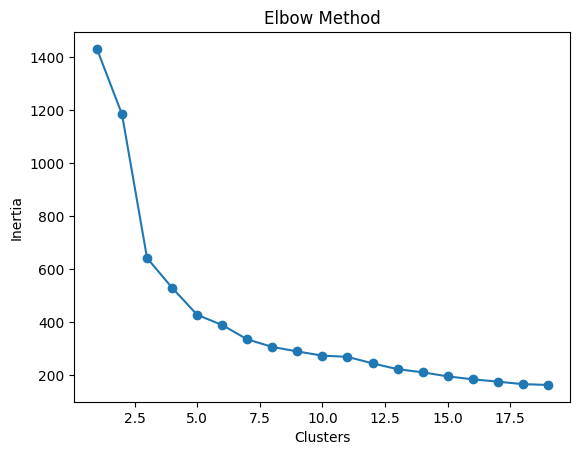

```python
optimal_clusters(X, 20)
```

```python
k_means = KMeans(n_clusters = 9, random_state = 42)
k_means.fit(X)
clusters = k_means.predict(X)
temp_df['Cluster'] = clusters
temp_df.head()
```

|  | Age | Job | Saving accounts | Checking account | Credit amount | Duration | Sex_male | Housing_own | Housing_rent | Purpose_car | Purpose_domestic appliances | Purpose_education | Purpose_furniture/equipment | Purpose_radio/TV | Purpose_repairs | Purpose_vacation/others | Cluster |
| --- | --- | --- | --- | --- | --- | --- | --- | --- | --- | --- | --- | --- | --- | --- | --- | --- | --- |
| 2 | 0.666667 | 1 | 0.0 | 0 | 0.241876 | 0.210526 | 1 | 1 | 0 | 0 | 0 | 1 | 0 | 0 | 0 | 0 | 5 |
| 3 | 0.577778 | 2 | 0.0 | 0 | 1.000000 | 1.000000 | 1 | 0 | 0 | 0 | 0 | 0 | 1 | 0 | 0 | 0 | 0 |
| 4 | 0.755556 | 2 | 0.0 | 0 | 0.605346 | 0.526316 | 1 | 0 | 0 | 1 | 0 | 0 | 0 | 0 | 0 | 0 | 0 |
| 6 | 0.755556 | 2 | 3.0 | 0 | 0.338705 | 0.526316 | 1 | 1 | 0 | 0 | 0 | 0 | 1 | 0 | 0 | 0 | 2 |
| 7 | 0.355556 | 3 | 0.0 | 1 | 0.877621 | 0.842105 | 1 | 0 | 1 | 1 | 0 | 0 | 0 | 0 | 0 | 0 | 6 |

```python
print('K-Means Inertial:', k_means.inertia_)
print('Silhouette Score:', silhouette_score(X, clusters))
```

```
K-Means Inertial: 288.0821941010043
Silhouette Score: 0.44988162606068194
```

```python
temp_df['Cluster'].unique()
```

```
array([5, 0, 2, 6, 7, 4, 3, 1, 8], dtype=int32)
```

```python
encoded_retail_df.columns
```

```
Index(['Transaction_ID', 'Date', 'Customer_Name', 'Product', 'Total_Items',
       'Total_Cost', 'City', 'Discount_Applied_0', 'Discount_Applied_1',
       'Payment_Method_Credit Card', 'Payment_Method_Debit Card',
       'Payment_Method_Mobile Payment', 'Store_Type_Department Store',
       'Store_Type_Pharmacy', 'Store_Type_Specialty Store',
       'Store_Type_Supermarket', 'Store_Type_Warehouse Club',
       'Customer_Category_Middle-Aged', 'Customer_Category_Professional',
       'Customer_Category_Retiree', 'Customer_Category_Senior Citizen',
       'Customer_Category_Student', 'Customer_Category_Teenager',
       'Customer_Category_Young Adult', 'Season_Spring', 'Season_Summer',
       'Season_Winter', 'Promotion_Discount on Selected Items',
       'Promotion_No Promotion'],
      dtype='object')
```

```python
# X_1 = encoded_retail_df[['Payment_Method_Credit Card', 'Payment_Method_Debit Card', 'Payment_Method_Mobile Payment',
#     'Store_Type_Department Store', 'Store_Type_Pharmacy', 'Store_Type_Specialty Store',
#     'Store_Type_Supermarket', 'Store_Type_Warehouse Club',
#     'Customer_Category_Middle-Aged', 'Customer_Category_Professional', 'Customer_Category_Retiree',
#     'Customer_Category_Senior Citizen', 'Customer_Category_Student', 'Customer_Category_Teenager',
#     'Customer_Category_Young Adult', 'Season_Spring', 'Season_Summer', 'Season_Winter',
#     'Promotion_Discount on Selected Items', 'Promotion_No Promotion', 'Total_Items', 'Total_Cost']]

X_1 = encoded_retail_df[['Payment_Method_Credit Card', 'Payment_Method_Debit Card', 'Payment_Method_Mobile Payment', 'Total_Cost', 'Total_Items']]

X_1.columns
```

```
Index(['Payment_Method_Credit Card', 'Payment_Method_Debit Card',
       'Payment_Method_Mobile Payment', 'Total_Cost', 'Total_Items'],
      dtype='object')
```

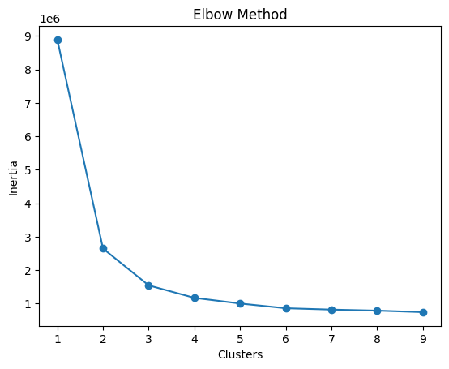

```python
optimal_clusters(X_1, 10)
```

```python
temp_df_1 = encoded_retail_df.copy()
k_means = KMeans(n_clusters = 4, random_state = 42)
k_means.fit(X_1)
clusters = k_means.predict(X_1)
temp_df_1['Cluster'] = clusters
temp_df_1.head()
```

|  | Transaction_ID | Date | Customer_Name | Product | Total_Items | Total_Cost | City | Discount_Applied_0 | Discount_Applied_1 | Payment_Method_Credit Card | ... | Customer_Category_Senior Citizen | Customer_Category_Student | Customer_Category_Teenager | Customer_Category_Young Adult | Season_Spring | Season_Summer | Season_Winter | Promotion_Discount on Selected Items | Promotion_No Promotion | Cluster |
| --- | --- | --- | --- | --- | --- | --- | --- | --- | --- | --- | --- | --- | --- | --- | --- | --- | --- | --- | --- | --- | --- |
| 0 | 1000000000 | 2022-01-21 06:27:29 | Stacey Price | ['Ketchup', 'Shaving Cream', 'Light Bulbs'] | 3 | 0.701579 | Los Angeles | 0 | 1 | 0 | ... | 0 | 0 | 0 | 0 | 0 | 0 | 1 | 0 | 1 | 2 |
| 1 | 1000000001 | 2023-03-01 13:01:21 | Michelle Carlson | ['Ice Cream', 'Milk', 'Olive Oil', 'Bread', 'P... | 2 | 0.220316 | San Francisco | 0 | 1 | 0 | ... | 0 | 0 | 0 | 0 | 0 | 0 | 0 | 0 | 0 | 2 |
| 2 | 1000000002 | 2024-03-21 15:37:04 | Lisa Graves | ['Spinach'] | 6 | 0.384105 | Houston | 0 | 1 | 1 | ... | 0 | 0 | 0 | 0 | 0 | 0 | 1 | 0 | 1 | 0 |
| 3 | 1000000003 | 2020-10-31 09:59:47 | Mrs. Patricia May | ['Tissues', 'Mustard'] | 1 | 0.361474 | Chicago | 0 | 1 | 0 | ... | 0 | 0 | 0 | 0 | 1 | 0 | 0 | 0 | 1 | 2 |
| 4 | 1000000004 | 2020-12-10 00:59:59 | Susan Mitchell | ['Dish Soap'] | 10 | 0.120211 | Houston | 1 | 0 | 0 | ... | 0 | 0 | 0 | 1 | 0 | 0 | 1 | 1 | 0 | 1 |

5 rows × 30 columns

## Principal Component Analysis

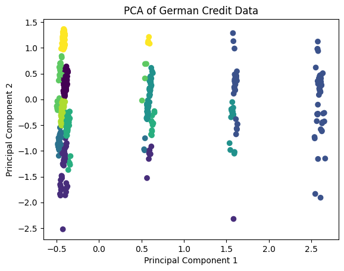

```python
pca = PCA(n_components = 2)
pca_german = pca.fit_transform(temp_df.drop('Cluster', axis = 1))
plt.scatter(pca_german[:, 0], pca_german[:, 1], c = temp_df['Cluster'], cmap = 'viridis')
plt.xlabel('Principal Component 1')
plt.ylabel('Principal Component 2')
plt.title('PCA of German Credit Data')
plt.show()
```

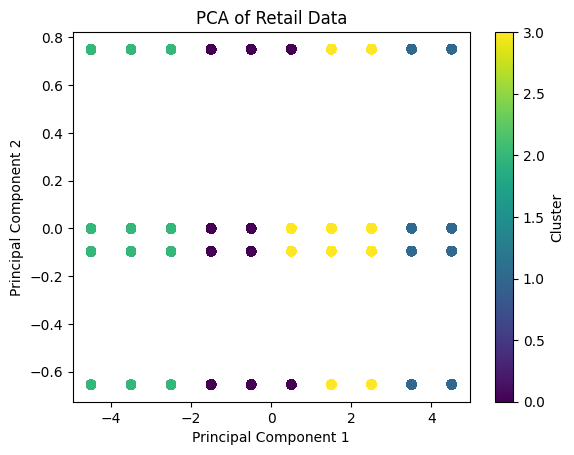

```python
pca_1 = PCA(n_components = 4)
pca_retail = pca_1.fit_transform(X_1)
plt.scatter(pca_retail[:, 0], pca_retail[:, 1], c = temp_df_1['Cluster'], cmap = 'viridis')
plt.xlabel('Principal Component 1')
plt.ylabel('Principal Component 2')
plt.title('PCA of Retail Data')
plt.colorbar(label = 'Cluster')
plt.show()
```

## Calculating metrics to calculate the risk score:

#### Credit Utilization Ratio, based on which Credit Utilization Score will be computed

#### Credit Per month, higher credit means higher risk

#### Housing risk, if rented higher risk due to instability

#### Savings account, absence of savings could mean potentially higher risk

```python
encoded_german_cleaned_df['Credit_Util_Ratio'] = np.where((encoded_german_cleaned_df['Saving accounts'] + encoded_german_cleaned_df['Checking account']) == 0, 1, encoded_german_cleaned_df['Credit amount'] / (encoded_german_cleaned_df['Saving accounts'] + encoded_german_cleaned_df['Checking account']))
```

```python
encoded_german_cleaned_df['Credit_Util_Ratio'].unique()
```

[output not shown]

[output cut: 22 more lines]

[output not shown]

```python
np.isinf(encoded_german_cleaned_df['Credit_Util_Ratio']).sum()
```

```
0
```

```python
def credit_util_score(ratio):
  # credit_util_ratio = row['Credit_Util_Ratio']

  if pd.isna(ratio) or np.isinf(ratio):
        return 1
  if ratio < 0.3:
    return 0
  elif ratio >= 0.3 and ratio <= 0.7:
    return 0.5
  else:
    return 1
```

```python
encoded_german_cleaned_df['Credit_Util_Score'] = encoded_german_cleaned_df['Credit_Util_Ratio'].apply(credit_util_score)
```

```python
encoded_german_cleaned_df['Credit_Util_Score'].describe()
```

[output not shown]

**dtype:** float64

```python
np.isinf(encoded_german_cleaned_df['Credit_Util_Score']).sum()
```

```
0
```

```python
encoded_german_cleaned_df['Saving accounts'].unique()
```

```
array([0., 3., 2., 1.])
```

```python
np.isinf(encoded_german_cleaned_df['Duration']).sum()
```

```
0
```

```python
(encoded_german_cleaned_df['Duration'] == 0).sum()
```

```
6
```

```python
encoded_german_cleaned_df[encoded_german_cleaned_df['Duration'] == 0]
```

|  | Age | Job | Saving accounts | Checking account | Credit amount | Duration | Sex_male | Housing_own | Housing_rent | Purpose_car | Purpose_domestic appliances | Purpose_education | Purpose_furniture/equipment | Purpose_radio/TV | Purpose_repairs | Purpose_vacation/others | Credit_Util_Ratio | Credit_Util_Score |
| --- | --- | --- | --- | --- | --- | --- | --- | --- | --- | --- | --- | --- | --- | --- | --- | --- | --- | --- |
| 234 | 0.511111 | 1 | 0.0 | 0 | 0.169549 | 0.0 | 1 | 1 | 0 | 0 | 0 | 0 | 0 | 1 | 0 | 0 | 1.000000 | 1.0 |
| 314 | 0.222222 | 1 | 0.0 | 2 | 0.162998 | 0.0 | 1 | 1 | 0 | 1 | 0 | 0 | 0 | 0 | 0 | 0 | 0.081499 | 0.0 |
| 527 | 0.511111 | 1 | 0.0 | 0 | 0.164177 | 0.0 | 1 | 1 | 0 | 0 | 0 | 0 | 0 | 1 | 0 | 0 | 1.000000 | 1.0 |
| 734 | 0.400000 | 2 | 0.0 | 0 | 0.410115 | 0.0 | 0 | 1 | 0 | 1 | 0 | 0 | 0 | 0 | 0 | 0 | 1.000000 | 1.0 |
| 837 | 0.088889 | 1 | 0.0 | 0 | 0.045991 | 0.0 | 0 | 0 | 1 | 0 | 0 | 0 | 1 | 0 | 0 | 0 | 1.000000 | 1.0 |
| 943 | 0.511111 | 1 | 0.0 | 0 | 0.157888 | 0.0 | 1 | 1 | 0 | 1 | 0 | 0 | 0 | 0 | 0 | 0 | 1.000000 | 1.0 |

```python
# encoded_german_cleaned_df = encoded_german_cleaned_df[encoded_german_cleaned_df['Duration'] != 0]
encoded_german_cleaned_df = encoded_german_cleaned_df.drop(encoded_german_cleaned_df[encoded_german_cleaned_df['Duration'] == 0].index, axis = 0)
```

```python
encoded_german_cleaned_df['Credit_Per_Month'] = encoded_german_cleaned_df['Credit amount'] / encoded_german_cleaned_df['Duration']
```

```python
encoded_german_cleaned_df['Credit_Per_Month'].unique()
```

[output not shown]

[output cut: 113 more lines]

[output not shown]

```python
np.isinf(encoded_german_cleaned_df['Credit_Per_Month']).sum()
```

```
0
```

```python
def housing_risk(row):
  if row['Housing_own'] == 1:
    return 0
  elif row['Housing_rent'] == 1:
    return 1
  else: # housing is free OR status is unknown
    return 0.5
```

```python
encoded_german_cleaned_df['Housing_Risk'] = encoded_german_cleaned_df.apply(housing_risk, axis = 1)
```

```python
def savings_risk(row):
  if row['Saving accounts'] == 0:
    return 1
  elif row['Saving accounts'] == 1:
    return 0.33
  elif row['Saving accounts'] == 2:
    return 0.66
  else:
    return 0
```

```python
encoded_german_cleaned_df['Savings_Risk'] = encoded_german_cleaned_df.apply(savings_risk, axis = 1)
```

```python
encoded_german_cleaned_df['Credit_Per_Month'].describe()
```

|  | Credit_Per_Month |
| --- | --- |
| count | 856.000000 |
| mean | 1.049467 |
| std | 1.173834 |
| min | 0.000000 |
| 25% | 0.464155 |
| 50% | 0.730710 |
| 75% | 1.167354 |
| max | 16.209251 |

**dtype:** float64

```python
high_threshold = encoded_german_cleaned_df['Credit_Per_Month'].quantile(0.95)
medium_threshold = encoded_german_cleaned_df['Credit_Per_Month'].quantile(0.05)
def credit_per_month_risk(row):
  if row['Credit_Per_Month'] > high_threshold:
    return 1
  elif row['Credit_Per_Month'] >= medium_threshold and row['Credit_Per_Month'] <= high_threshold:
    return 0
  else:
    return 0.5
```

```python
encoded_german_cleaned_df['Credit_Per_Month_Risk'] = encoded_german_cleaned_df.apply(credit_per_month_risk, axis=1)
```

```python
# Risk Score = (Credit Amount / Duration) + (Credit Utilization Ratio) + (Hosuing Risk) + (Savings Risk)
encoded_german_cleaned_df['Risk_Score_Raw_Credit'] = encoded_german_cleaned_df['Credit_Per_Month'] + encoded_german_cleaned_df['Credit_Util_Score'] + encoded_german_cleaned_df['Housing_Risk'] + encoded_german_cleaned_df['Savings_Risk']
encoded_german_cleaned_df['Risk_Score_Scored_Credit'] = encoded_german_cleaned_df['Credit_Per_Month_Risk'] + encoded_german_cleaned_df['Credit_Util_Score'] + encoded_german_cleaned_df['Housing_Risk'] + encoded_german_cleaned_df['Savings_Risk']
encoded_german_cleaned_df
```

|  | Age | Job | Saving accounts | Checking account | Credit amount | Duration | Sex_male | Housing_own | Housing_rent | Purpose_car | ... | Purpose_repairs | Purpose_vacation/others | Credit_Util_Ratio | Credit_Util_Score | Credit_Per_Month | Housing_Risk | Savings_Risk | Credit_Per_Month_Risk | Risk_Score_Raw_Credit | Risk_Score_Scored_Credit |
| --- | --- | --- | --- | --- | --- | --- | --- | --- | --- | --- | --- | --- | --- | --- | --- | --- | --- | --- | --- | --- | --- |
| 2 | 0.666667 | 1 | 0.0 | 0 | 0.241876 | 0.210526 | 1 | 1 | 0 | 0 | ... | 0 | 0 | 1.000000 | 1.0 | 1.148912 | 0.0 | 1.0 | 0.0 | 3.148912 | 2.0 |
| 3 | 0.577778 | 2 | 0.0 | 0 | 1.000000 | 1.000000 | 1 | 0 | 0 | 0 | ... | 0 | 0 | 1.000000 | 1.0 | 1.000000 | 0.5 | 1.0 | 0.0 | 3.500000 | 2.5 |
| 4 | 0.755556 | 2 | 0.0 | 0 | 0.605346 | 0.526316 | 1 | 0 | 0 | 1 | ... | 0 | 0 | 1.000000 | 1.0 | 1.150157 | 0.5 | 1.0 | 0.0 | 3.650157 | 2.5 |
| 6 | 0.755556 | 2 | 3.0 | 0 | 0.338705 | 0.526316 | 1 | 1 | 0 | 0 | ... | 0 | 0 | 0.112902 | 0.0 | 0.643540 | 0.0 | 0.0 | 0.0 | 0.643540 | 0.0 |
| 7 | 0.355556 | 3 | 0.0 | 1 | 0.877621 | 0.842105 | 1 | 0 | 1 | 1 | ... | 0 | 0 | 0.877621 | 1.0 | 1.042174 | 1.0 | 1.0 | 0.0 | 4.042174 | 3.0 |
| ... | ... | ... | ... | ... | ... | ... | ... | ... | ... | ... | ... | ... | ... | ... | ... | ... | ... | ... | ... | ... | ... |
| 993 | 0.244444 | 3 | 0.0 | 0 | 0.485980 | 0.842105 | 1 | 1 | 0 | 0 | ... | 0 | 0 | 1.000000 | 1.0 | 0.577101 | 0.0 | 1.0 | 0.0 | 2.577101 | 2.0 |
| 994 | 0.688889 | 2 | 0.0 | 0 | 0.280398 | 0.210526 | 1 | 1 | 0 | 1 | ... | 0 | 0 | 1.000000 | 1.0 | 1.331892 | 0.0 | 1.0 | 0.0 | 3.331892 | 2.0 |
| 995 | 0.266667 | 1 | 0.0 | 0 | 0.194706 | 0.210526 | 0 | 1 | 0 | 0 | ... | 0 | 0 | 1.000000 | 1.0 | 0.924856 | 0.0 | 1.0 | 0.0 | 2.924856 | 2.0 |
| 996 | 0.466667 | 3 | 0.0 | 0 | 0.472615 | 0.684211 | 1 | 1 | 0 | 1 | ... | 0 | 0 | 1.000000 | 1.0 | 0.690745 | 0.0 | 1.0 | 0.0 | 2.690745 | 2.0 |
| 997 | 0.422222 | 2 | 0.0 | 0 | 0.072589 | 0.210526 | 1 | 1 | 0 | 0 | ... | 0 | 0 | 1.000000 | 1.0 | 0.344798 | 0.0 | 1.0 | 0.0 | 2.344798 | 2.0 |

856 rows × 24 columns

```python
encoded_german_cleaned_df['Risk_Score_Raw_Credit'].describe()
```

|  | Risk_Score_Raw_Credit |
| --- | --- |
| count | 856.000000 |
| mean | 2.723813 |
| std | 1.480983 |
| min | 0.102537 |
| 25% | 1.900127 |
| 50% | 2.585454 |
| 75% | 3.316050 |
| max | 18.209251 |

**dtype:** float64

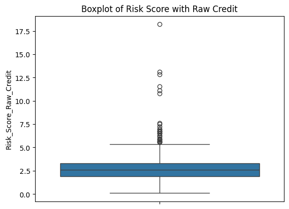

```python
sns.boxplot(encoded_german_cleaned_df['Risk_Score_Raw_Credit'])
plt.title('Boxplot of Risk Score with Raw Credit')
plt.show()
```

```python
encoded_german_cleaned_df['Risk_Score_Scored_Credit'].describe()
```

|  | Risk_Score_Scored_Credit |
| --- | --- |
| count | 856.000000 |
| mean | 1.749112 |
| std | 0.847461 |
| min | 0.000000 |
| 25% | 1.000000 |
| 50% | 2.000000 |
| 75% | 2.000000 |
| max | 4.000000 |

**dtype:** float64

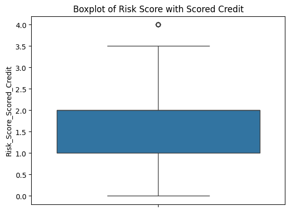

```python
sns.boxplot(encoded_german_cleaned_df['Risk_Score_Scored_Credit'])
plt.title('Boxplot of Risk Score with Scored Credit')
plt.show()
```

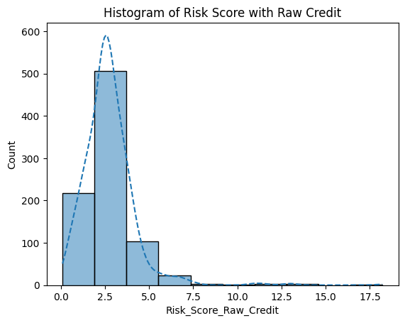

```python
sns.histplot(encoded_german_cleaned_df['Risk_Score_Raw_Credit'], bins = 10, kde = True, line_kws = {'color': 'crimson', 'ls': '--'})
plt.title('Histogram of Risk Score with Raw Credit')
plt.show()
```

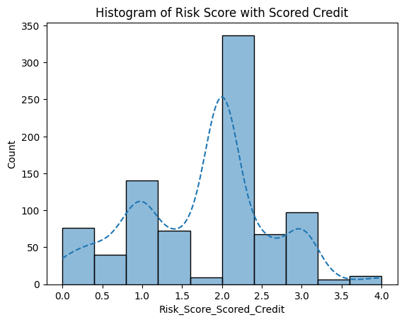

```python
sns.histplot(encoded_german_cleaned_df['Risk_Score_Scored_Credit'], bins = 10, kde = True, line_kws = {'color': 'crimson', 'ls': '--'})
plt.title('Histogram of Risk Score with Scored Credit')
plt.show()
```

```python
correlation_matrix = encoded_german_cleaned_df.corr()
print(correlation_matrix['Risk_Score_Raw_Credit'].sort_values(ascending=False))
```

```
Risk_Score_Raw_Credit          1.000000
Credit_Per_Month               0.840979
Risk_Score_Scored_Credit       0.720823
Credit_Util_Score              0.516020
Credit_Util_Ratio              0.510119
Credit_Per_Month_Risk          0.490397
Savings_Risk                   0.383260
Credit amount                  0.359603
Housing_Risk                   0.337006
Housing_rent                   0.316596
Purpose_car                    0.113846
Purpose_furniture/equipment    0.095230
Job                            0.086158
Age                            0.023035
Sex_male                       0.005655
Purpose_vacation/others        0.004341
Purpose_education             -0.010117
Purpose_domestic appliances   -0.043688
Purpose_repairs               -0.053820
Purpose_radio/TV              -0.106619
Checking account              -0.241724
Duration                      -0.249425
Housing_own                   -0.323305
Saving accounts               -0.370157
Name: Risk_Score_Raw_Credit, dtype: float64
```

```python
def risk_category(score):
  if score < 1:
    return 'low'
  elif score >= 1 and score <= 2.5:
    return 'medium'
  else:
    return 'high'
```

```python
encoded_german_cleaned_df['Risk_Category_Scored_Credit'] = encoded_german_cleaned_df['Risk_Score_Scored_Credit'].apply(risk_category)
encoded_german_cleaned_df.head()
```

|  | Age | Job | Saving accounts | Checking account | Credit amount | Duration | Sex_male | Housing_own | Housing_rent | Purpose_car | ... | Purpose_vacation/others | Credit_Util_Ratio | Credit_Util_Score | Credit_Per_Month | Housing_Risk | Savings_Risk | Credit_Per_Month_Risk | Risk_Score_Raw_Credit | Risk_Score_Scored_Credit | Risk_Category_Scored_Credit |
| --- | --- | --- | --- | --- | --- | --- | --- | --- | --- | --- | --- | --- | --- | --- | --- | --- | --- | --- | --- | --- | --- |
| 2 | 0.666667 | 1 | 0.0 | 0 | 0.241876 | 0.210526 | 1 | 1 | 0 | 0 | ... | 0 | 1.000000 | 1.0 | 1.148912 | 0.0 | 1.0 | 0.0 | 3.148912 | 2.0 | medium |
| 3 | 0.577778 | 2 | 0.0 | 0 | 1.000000 | 1.000000 | 1 | 0 | 0 | 0 | ... | 0 | 1.000000 | 1.0 | 1.000000 | 0.5 | 1.0 | 0.0 | 3.500000 | 2.5 | medium |
| 4 | 0.755556 | 2 | 0.0 | 0 | 0.605346 | 0.526316 | 1 | 0 | 0 | 1 | ... | 0 | 1.000000 | 1.0 | 1.150157 | 0.5 | 1.0 | 0.0 | 3.650157 | 2.5 | medium |
| 6 | 0.755556 | 2 | 3.0 | 0 | 0.338705 | 0.526316 | 1 | 1 | 0 | 0 | ... | 0 | 0.112902 | 0.0 | 0.643540 | 0.0 | 0.0 | 0.0 | 0.643540 | 0.0 | low |
| 7 | 0.355556 | 3 | 0.0 | 1 | 0.877621 | 0.842105 | 1 | 0 | 1 | 1 | ... | 0 | 0.877621 | 1.0 | 1.042174 | 1.0 | 1.0 | 0.0 | 4.042174 | 3.0 | high |

5 rows × 25 columns

```python
encoded_german_cleaned_df['Risk_Category_Scored_Credit'].value_counts()
```

| Risk_Category_Scored_Credit | count |
| --- | --- |
| medium | 605 |
| low | 137 |
| high | 114 |

**dtype:** int64

# Building models to predict the risk score

```python
from sklearn.linear_model import LogisticRegression
from sklearn.model_selection import train_test_split
from sklearn.model_selection import GridSearchCV
from sklearn.metrics import accuracy_score, precision_score, recall_score, f1_score, roc_auc_score
```

```python
risk_order = ['low', 'medium', 'high']
encoder = OrdinalEncoder(categories = [risk_order])
encoded_german_cleaned_df['Risk_Category_Scored_Credit'] = encoder.fit_transform(encoded_german_cleaned_df[['Risk_Category_Scored_Credit']])
encoded_german_cleaned_df.head()
```

|  | Age | Job | Saving accounts | Checking account | Credit amount | Duration | Sex_male | Housing_own | Housing_rent | Purpose_car | ... | Purpose_vacation/others | Credit_Util_Ratio | Credit_Util_Score | Credit_Per_Month | Housing_Risk | Savings_Risk | Credit_Per_Month_Risk | Risk_Score_Raw_Credit | Risk_Score_Scored_Credit | Risk_Category_Scored_Credit |
| --- | --- | --- | --- | --- | --- | --- | --- | --- | --- | --- | --- | --- | --- | --- | --- | --- | --- | --- | --- | --- | --- |
| 2 | 0.666667 | 1 | 0.0 | 0 | 0.241876 | 0.210526 | 1 | 1 | 0 | 0 | ... | 0 | 1.000000 | 1.0 | 1.148912 | 0.0 | 1.0 | 0.0 | 3.148912 | 2.0 | 1.0 |
| 3 | 0.577778 | 2 | 0.0 | 0 | 1.000000 | 1.000000 | 1 | 0 | 0 | 0 | ... | 0 | 1.000000 | 1.0 | 1.000000 | 0.5 | 1.0 | 0.0 | 3.500000 | 2.5 | 1.0 |
| 4 | 0.755556 | 2 | 0.0 | 0 | 0.605346 | 0.526316 | 1 | 0 | 0 | 1 | ... | 0 | 1.000000 | 1.0 | 1.150157 | 0.5 | 1.0 | 0.0 | 3.650157 | 2.5 | 1.0 |
| 6 | 0.755556 | 2 | 3.0 | 0 | 0.338705 | 0.526316 | 1 | 1 | 0 | 0 | ... | 0 | 0.112902 | 0.0 | 0.643540 | 0.0 | 0.0 | 0.0 | 0.643540 | 0.0 | 0.0 |
| 7 | 0.355556 | 3 | 0.0 | 1 | 0.877621 | 0.842105 | 1 | 0 | 1 | 1 | ... | 0 | 0.877621 | 1.0 | 1.042174 | 1.0 | 1.0 | 0.0 | 4.042174 | 3.0 | 2.0 |

5 rows × 25 columns

```python
X = encoded_german_cleaned_df[['Credit_Per_Month_Risk', 'Credit_Util_Score', 'Housing_Risk', 'Savings_Risk']]
y = encoded_german_cleaned_df['Risk_Category_Scored_Credit']

X_train, X_test, y_train, y_test = train_test_split(X, y, test_size = 0.2, random_state = 42)
```

```python
logistic_model = LogisticRegression()
logistic_model.fit(X_train, y_train)
y_pred = logistic_model.predict(X_test)
```

```python
print('Accuracy:', accuracy_score(y_test, y_pred))
print('Precision:', precision_score(y_test, y_pred, average = 'weighted'))
print('Recall:', recall_score(y_test, y_pred, average = 'weighted'))
print('F1 Score:', f1_score(y_test, y_pred, average = 'weighted'))
```

```
Accuracy: 0.936046511627907
Precision: 0.9371119191630408
Recall: 0.936046511627907
F1 Score: 0.9310093079271424
```

```python
y_pred = logistic_model.predict_proba(X_test)
print('ROC AUC Score:', roc_auc_score(y_test, y_pred, multi_class = 'ovr'))
```

```
ROC AUC Score: 0.9971139971139972
```

### Tesing the model on random inputs

```python
unique_credit_per_month_risk = encoded_german_cleaned_df['Credit_Per_Month_Risk'].unique()
unique_credit_util_score = encoded_german_cleaned_df['Credit_Util_Score'].unique()
unique_housing_risk = encoded_german_cleaned_df['Housing_Risk'].unique()
unique_savings_risk = encoded_german_cleaned_df['Savings_Risk'].unique()

print("Unique values in 'Credit_Per_Month_Risk':", unique_credit_per_month_risk)
print("Unique values in 'Credit_Util_Score':", unique_credit_util_score)
print("Unique values in 'Housing_Risk':", unique_housing_risk)
print("Unique values in 'Savings_Risk':", unique_savings_risk)
```

```
Unique values in 'Credit_Per_Month_Risk': [0.  0.5 1. ]
Unique values in 'Credit_Util_Score': [1.  0.  0.5]
Unique values in 'Housing_Risk': [0.  0.5 1. ]
Unique values in 'Savings_Risk': [1.   0.   0.66 0.33]
```

```python
# inputs: ['Credit_Per_Month_Risk', 'Credit_Util_Score', 'Housing_Risk', 'Savings_Risk']]
#           [0, 0.5,1]                 [0, 0.5, 1        [0, 0.5, 1]     [0, 0.33, 0.66, 1]
```

```python
input = np.array([[1, 0, 0, 0.33]])
predicted_risk = logistic_model.predict(input)

risks = {0 : 'low', 1 : 'medium', 2 : 'high'}
predicted_risk_mapped = risks[predicted_risk[0]]

print("Predicted Risk Category:", predicted_risk[0], '-', predicted_risk_mapped)
```

```
Predicted Risk Category: 1.0 - medium
```

```python
input = np.array([[0, 0, 1, 1]])
predicted_risk = logistic_model.predict(input)

risks = {0 : 'low', 1 : 'medium', 2 : 'high'}
predicted_risk_mapped = risks[predicted_risk[0]]

print("Predicted Risk Category:", predicted_risk[0], '-', predicted_risk_mapped)
```

```
Predicted Risk Category: 2.0 - high
```